# K-Means Clustering of Stocks

A stock is a type of investment that represents an ownership share in a company. Investors buy stocks that they think will go up in value over time. Therefore, AI could offer investors a great tool that would help them make more money by assisting them in choosing the stock with a better chance of increasing in share value.

We used clustering to make sense of the numerous stock data that the stock market offer. We also used it to group data into similar clusters. Then, these clustered data would help us in stock prediction. We used the K-Means clustering algorithm since our data is unlabeled and for reliability. The goal of this algorithm is to find groups in the data, with the number of groups represented by the variable K.

### Modules used:

###### requests:

used to request stocks information from tdamertrade.com

###### pandas:

important dataframe module, it is the most popular python module

###### warnings:

ignores warnings for aesthetic reasons

###### numpy:

important module for manipulating arrays and matrices, it is the second most popular python module

###### matplotlib:

important to plot graphs

###### sklearn:

will play a huge part in clustering and manipulating the data itself

###### yellowbrick:

important to visualize silhouette

###### The code will most likely not run on your personal computer due to yellowbrick needing an older version of python, please import the necessary modules before running the code as we had to install special unofficial wheels in order for our code to work on our computers.

```python
import requests

import pandas as pd

import warnings
warnings.filterwarnings('ignore')

import numpy as np

%matplotlib inline
import matplotlib.pyplot as plt
from mpl_toolkits.mplot3d import Axes3D

from yellowbrick.cluster import SilhouetteVisualizer

from sklearn.cluster import KMeans
from sklearn import metrics
from sklearn.decomposition import PCA
from sklearn.preprocessing import Normalizer
from sklearn.preprocessing import RobustScaler
from sklearn.preprocessing import MinMaxScaler, StandardScaler
```

Stock symbols are saved in a csv file (a comma-separated values file).

We have 10000 stock symbols in the csv file that we extracted ourselves.

The symbols will be used later in order to extract the data.

```python
stock_symbols = pd.read_csv("stocks.csv")
```

Since the server we extract information from cannot handle more than 100 requests at a time, we are forced to break our data into chunks of 100 to issue multiple consecutive requests and the response will end up being appended together. List comprehension is used in order to get "chunk" as a list instead of a dataframe in one line.

```python
n = 100

chunk = [stock_symbols[i:i+n] for i in range( 0, stock_symbols.shape[0], n)]
```

Now we request our information using a for loop to request multiple chunks of data using the get method and convert this data into a JSON. Try/except are used in order to ignore any symbol that could not be found. A CUSIP is a nine-digit numeric or nine-character alphanumeric code that identifies a North American financial security, in short it will only be used to track the symbol. We then create the dataframe that will be displayed below.

```python
server = r"https://api.tdameritrade.com/v1/instruments"

stocks = {}

for c in chunk:

    request = {'apikey':'OXF4DMJMNTVKJ0OEGMMGDI43EQFBUDEM',
               'projection':'fundamental',
               'symbol':list(c['Symbol'])}

    content = requests.get(url = server, params = request)

    data = content.json()

    try:
        for stock in data:
            stocks[data[stock]['cusip']] = data[stock]['fundamental']
    except:
        continue

df = pd.DataFrame(stocks)
```

```python
df = df.transpose()

df

df.to_csv("test.csv")
```

An indicator is a mathematical calculation based on historic price, volume, or open interest information. Investors use these indicators to forecast financial market direction. Therefore, it only makes sense that we choose to cluster our stock data according to the indicators that offer useful structure to the data.

After some research we found out that the best indicators to cluster our data with are these three.

**Return on Assets:** It indicates how efficient the company is managing its assets to generate earning. Thus, if it’s making a good job, we should be able to see a good return on assets.

**Return on Equity:** It indicates how the company is using its equity to make profit which is another company performance indicator.

**Return on Investment:** It indicates how well this stock has been doing as an investment.

Therefore, if a stock is doing great in all of these indicators, we should expect an increase in the stock value. This is still not enough for accurate prediction, but it does yield higher probability.

We define the list of attributes we want to extract and work with.

```python
attributes = ['returnOnEquity','returnOnAssets','returnOnInvestment','symbol']

attributes_df = df[attributes]

attributes_df
```

|  | returnOnEquity | returnOnAssets | returnOnInvestment | symbol |
| --- | --- | --- | --- | --- |
| 23204X103 | 0.0 | 0.0 | 0.0 | CTOS |
| 603380106 | 0.0 | 0.0 | 0.0 | NERV |
| 76761L102 | 0.0 | 0.0 | 0.0 | REDU |
| 32106V107 | 11.37968 | 0.98602 | 0.0 | FXNC |
| 294766100 | 0.0 | 0.0 | 0.0 | EQS |
| ... | ... | ... | ... | ... |
| 96951B201 | 0.0 | 0.0 | 0.0 | WRAC/U |
| 848651204 | 0.0 | 0.0 | 0.0 | SPKAU |
| 08069M201 | 0.0 | 0.0 | 0.0 | BLNGU |
| G0542N107 | 0.0 | 0.0 | 0.0 | RAM |
| G0083E102 | 0.0 | 0.0 | 0.0 | ACBA |

6811 rows × 4 columns

As we can see, we have a lot of missing values (0.0) in numerous columns. Since clustering is not really fond of missing values, we drop any row that contains missing values.

```python
attributes_df = attributes_df[attributes_df[attributes] != 0]

attributes_df = attributes_df.dropna(how='any')

attributes_df
```

|  | returnOnEquity | returnOnAssets | returnOnInvestment | symbol |
| --- | --- | --- | --- | --- |
| 59522J103 | 7.2189 | 3.97467 | 4.27593 | MAA |
| 68622D106 | 2.21102 | 1.78224 | 1.82385 | ORGN |
| 60770K107 | 109.6185 | 55.22445 | 99.8566 | MRNA |
| G2181K105 | 4.99605 | 6.87883 | 7.91629 | CNEY |
| 87612E106 | 50.01106 | 12.90924 | 21.74973 | TGT |
| ... | ... | ... | ... | ... |
| Y0436Q109 | 4.65188 | 2.36635 | 2.59688 | ATCO |
| 447324104 | 0.45226 | 0.34859 | 0.43204 | HURC |
| 045327103 | 54.40211 | 25.34717 | 30.174 | AZPN |
| 39959A106 | 31.82258 | 22.05362 | 31.02169 | GRVI |
| 71844V201 | 0.46418 | 0.22391 | 0.247 | PECO |

2437 rows × 4 columns

As we can see we do not have a set index, so we set the symbols as the indices in order to manipulate the dataframes later.

```python
attributes_df = attributes_df.set_index('symbol')
```

We then convert the dataframe type to floats as our information is represented as floats.

```python
attributes_df = attributes_df.astype('float')

attributes_df
```

| symbol | returnOnEquity | returnOnAssets | returnOnInvestment |
| --- | --- | --- | --- |
| MAA | 7.21890 | 3.97467 | 4.27593 |
| ORGN | 2.21102 | 1.78224 | 1.82385 |
| MRNA | 109.61850 | 55.22445 | 99.85660 |
| CNEY | 4.99605 | 6.87883 | 7.91629 |
| TGT | 50.01106 | 12.90924 | 21.74973 |
| ... | ... | ... | ... |
| ATCO | 4.65188 | 2.36635 | 2.59688 |
| HURC | 0.45226 | 0.34859 | 0.43204 |
| AZPN | 54.40211 | 25.34717 | 30.17400 |
| GRVI | 31.82258 | 22.05362 | 31.02169 |
| PECO | 0.46418 | 0.22391 | 0.24700 |

2437 rows × 3 columns

For more accurate clustering and since K-means is sensitive to outliers, we have to remove all the outlier companies that have extreme indicator values. For example, a company might have 16000% as a Return on Equity value but this is not very reflective of a traditional company. This might happen due to having a small equity base with large revenue in the denominator. Since K-means is sensitive to outliers we removed them.

In our code, we kept all rows that have their equity under 40, and their assets and investments under 30.

First we define our attribute locations (we already know which column is on which index) with the new constraint, then we filter the dataframe accordingly.

```python
equity = attributes_df.iloc[:,0] <40
assets = attributes_df.iloc[:,1] <30
investments = attributes_df.iloc[:,2] <30

attributes_df = attributes_df[equity & assets & investments]

attributes_df

attributes_df.to_csv("attributes.csv")
```

Now for demonstration purposes, we will be showing how the data looks like plotted before clustering in a 3D model based on the 3 attributes we chose using matlibplot. As we can see, a lot of companies are stacked in the bottom left while we see scattering as we move farther from that stacked area

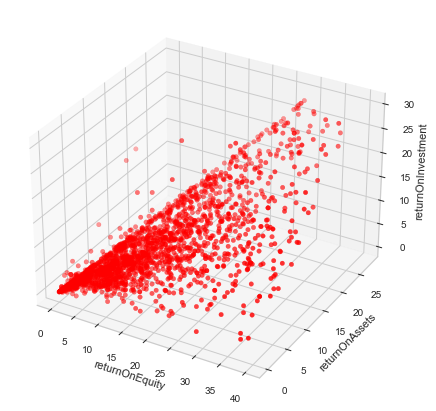

```python
figure = plt.figure()
a = Axes3D(figure)

x = list(attributes_df.iloc[:,0])
y = list(attributes_df.iloc[:,1])
z = list(attributes_df.iloc[:,2])

names = attributes_df.columns
a.set_xlabel(names[0])
a.set_ylabel(names[1])
a.set_zlabel(names[2])

a.scatter(x, y, z, c='Red', marker='o')

plt.show()
```

As we said K-means is really sensitive to outliers, hence why we have to normalize the data using scalers that are present in sklearn. There are multiple scalers present but most of them are susceptible to outliers, hence we are going to use the robust scaler which is explained below.

**min-max scaler:** This method scales data to be between 0 and 1 by subtracting the minimum from each data point and dividing it by the difference of the max and min values. This is extremely sensitive to outliers as the min and max values tend to obviously be outliers.

**standard scaler:** This method divides the mean by the standard deviation after subtracting it from each data point. This scaler is sensitive to outliers.

**robust scaler:** This method uses the the difference between smallest value and the largest value of the middle 50% of a set of data instead of the minimum and maximum. Hence, this method is the least susceptible to outliers which we will use.

Sklearn already has the methods made for us so we only have to bring them to our code.

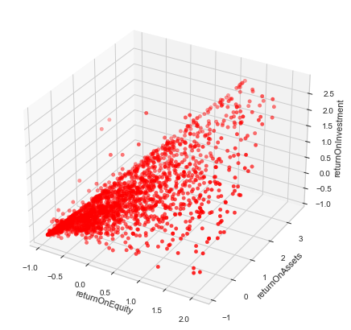

```python
scaler = RobustScaler()

scaled_robust = scaler.fit_transform(attributes_df)

figure = plt.figure()
a = Axes3D(figure)

x = scaled_robust[:,0]
y = scaled_robust[:,1]
z = scaled_robust[:,2]

names = attributes_df.columns
a.set_xlabel(names[0])
a.set_ylabel(names[1])
a.set_zlabel(names[2])

a.scatter(x, y, z, c='Red')

plt.show()
```

Since we have large data sets with multiple attributes, we decided to include Principal Component Analysis (PCA) to make our model have less redundant data and run faster. In our project, the use of PCA is simply to check whether having 3 attributes is actually beneficial to us or whether it barely adds new information. In this way, we can keep only the most essential attributes and get rid of the useless ones.

Luckily, sklearn has PCA made for us, so we combine pca and numpy's cumulative sum method in order to plot the variance.

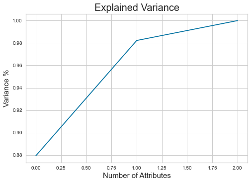

```python
pca = PCA().fit(scaled_robust)

plt.figure()
plt.plot(np.cumsum(pca.explained_variance_ratio_))

plt.xlabel('Number of Attributes', fontsize = 15)
plt.ylabel('Variance %', fontsize = 15)
plt.title('Explained Variance', fontsize = 20)

plt.show()
```

Now we create a new dataset that is modified by pca using two components only and turn it into a dataframe as shown below.

```python
pca_dataset = PCA(n_components=2).fit(scaled_robust).transform(scaled_robust)

pca_dataset= pd.DataFrame(data = pca_dataset, columns = ['component 1', 'component 2'])

pca_dataset
```

|  | component 1 | component 2 |
| --- | --- | --- |
| 0 | -0.825108 | -0.138128 |
| 1 | -1.410941 | -0.242643 |
| 2 | -0.352996 | -0.596760 |
| 3 | -0.811603 | 0.128510 |
| 4 | -0.346938 | -0.186179 |
| ... | ... | ... |
| 2050 | -1.461845 | 0.026578 |
| 2051 | -0.196197 | 0.396276 |
| 2052 | -1.204586 | -0.145488 |
| 2053 | -1.721681 | -0.217537 |
| 2054 | -1.747181 | -0.202459 |

2055 rows × 2 columns

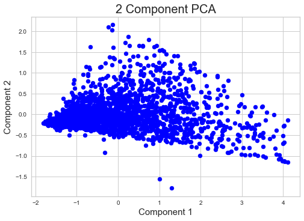

```python
plt.figure()

plt.xlabel('Component 1', fontsize = 15)
plt.ylabel('Component 2', fontsize = 15)
plt.title('2 Component PCA', fontsize = 20)

plt.scatter(pca_dataset['component 1'], pca_dataset['component 2'], c='Blue', s = 50)
```

As we can see, using two components only we got extremely similar results compared to not using PCA at all. Again, this step was for demonstration purposes and to explain more about the nature of K-means clustering.

Now that we are done with visualizing the model in order to understand it, we will start clustering down below.

In order to K-means cluster, we have to determine K. Now there are many approaches to determine K, but we opted with the silhouette approach as it is simple to visualize. Silhouette analysis approach studies the distance between each cluster. And since we want our clusters to be distinct from each other, we need our clusters to be distanced from each other. Silhouette approach measures that distance as a silhouette coefficient in a range between (-1,1) where 1 indicates that the clusters are far from each other which is the desired result. We will test multiple Ks to find out which K results in the highest coefficient in order to choose.

We will start with 2 clusters till 10 as having 1 cluster is illogical.

We will be using sklearn heavily here, especially kmeans and metrics which are imported above. We will base our metric on the euclidean metric which is the most popular to base our silhouette score on.

We will do one calculation with no PCA and another with PCA.

```python
results_dict= {}

for k in range(2, 11):

    print("-"*120)

    results_dict[k] = {}

    kmeans = KMeans(n_clusters=k, random_state=0).fit(scaled_robust)

    sil_score = metrics.silhouette_score(scaled_robust, kmeans.labels_, metric='euclidean')

    results_dict[k]['silhouette_score'] = sil_score
    results_dict[k]['model'] = kmeans
    print("Number of Clusters: {}".format(k))
    print('Silhouette Score:', sil_score)

print("-"*120)
```

```
------------------------------------------------------------------------------------------------------------------------
Number of Clusters: 2
Silhouette Score: 0.5349622139042662
------------------------------------------------------------------------------------------------------------------------
Number of Clusters: 3
Silhouette Score: 0.4590112687512708
------------------------------------------------------------------------------------------------------------------------
Number of Clusters: 4
Silhouette Score: 0.4117844259459351
------------------------------------------------------------------------------------------------------------------------
Number of Clusters: 5
Silhouette Score: 0.41599260974282803
------------------------------------------------------------------------------------------------------------------------
Number of Clusters: 6
Silhouette Score: 0.37919071953797284
------------------------------------------------------------------------------------------------------------------------
Number of Clusters: 7
Silhouette Score: 0.35865841688832784
------------------------------------------------------------------------------------------------------------------------
Number of Clusters: 8
Silhouette Score: 0.3636873986306978
------------------------------------------------------------------------------------------------------------------------
Number of Clusters: 9
Silhouette Score: 0.3507816671546408
------------------------------------------------------------------------------------------------------------------------
Number of Clusters: 10
Silhouette Score: 0.347403276131423
------------------------------------------------------------------------------------------------------------------------
```

As we can see, the fewer clusters the higher score we are getting. However, keep in mind this is not a rule and it only happened coincidentally for us. 0.57 is generally a good score, and a score starting from 0.45 is generally accepted.

Now for our PCA run:

```python
results_pca = {}

for k in range(2, 11):

    print("-"*120)

    results_pca[k] = {}

    kmeans = KMeans(n_clusters=k, random_state=0).fit(pca_dataset)

    sil_score = metrics.silhouette_score(pca_dataset, kmeans.labels_, metric='euclidean')

    results_pca[k]['silhouette_score'] = sil_score
    results_pca[k]['model'] = kmeans
    print("Number of Clusters: {}".format(k))
    print('Silhouette Score:', sil_score)

print("-"*120)
```

```
------------------------------------------------------------------------------------------------------------------------
Number of Clusters: 2
Silhouette Score: 0.5442563910443841
------------------------------------------------------------------------------------------------------------------------
Number of Clusters: 3
Silhouette Score: 0.4727868259023442
------------------------------------------------------------------------------------------------------------------------
Number of Clusters: 4
Silhouette Score: 0.4296074137638129
------------------------------------------------------------------------------------------------------------------------
Number of Clusters: 5
Silhouette Score: 0.4337575123115725
------------------------------------------------------------------------------------------------------------------------
Number of Clusters: 6
Silhouette Score: 0.40276928689879793
------------------------------------------------------------------------------------------------------------------------
Number of Clusters: 7
Silhouette Score: 0.4103949096744778
------------------------------------------------------------------------------------------------------------------------
Number of Clusters: 8
Silhouette Score: 0.3911382417993779
------------------------------------------------------------------------------------------------------------------------
Number of Clusters: 9
Silhouette Score: 0.38150266032474156
------------------------------------------------------------------------------------------------------------------------
Number of Clusters: 10
Silhouette Score: 0.381647707170149
------------------------------------------------------------------------------------------------------------------------
```

Now we have to visualize the silhouettes to help us determine K too as we cannot just pick based on the scores above. We will use SilhouetteVisualizer from yellowbrick in order to do so.

We will focus on 2, 3, and 5 clusters only as they gave the best 3 results for no PCA and with PCA.

We will run two calculations, one with and one without PCA.

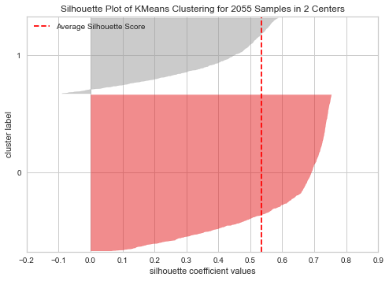

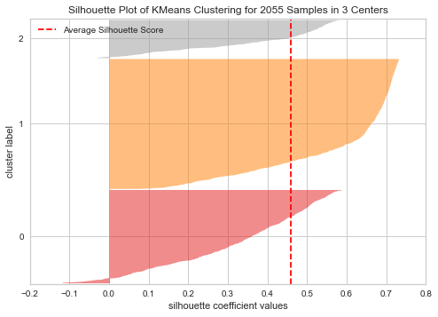

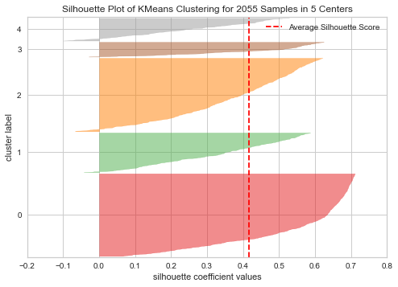

```python
clusters = [2,3,5]

for cluster in clusters:

    print('-'*120)

    kmeans = KMeans(n_clusters = cluster, random_state=0)

    visualizer = SilhouetteVisualizer(kmeans)

    visualizer.fit(scaled_robust)

    visualizer.poof()
```

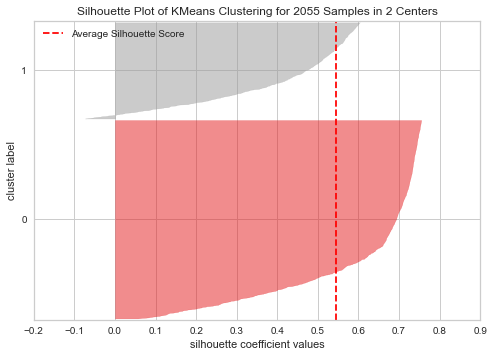

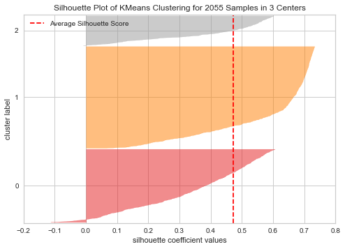

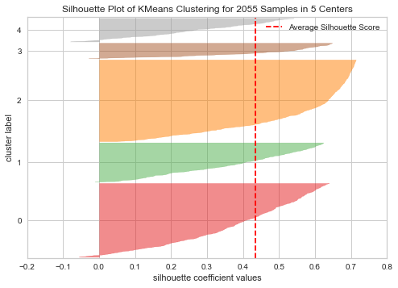

```python
clusters = [2,3,5]

for cluster in clusters:

    print('-'*100)

    kmeans = KMeans(n_clusters = cluster, random_state=0)

    visualizer = SilhouetteVisualizer(kmeans)

    visualizer.fit(pca_dataset)

    visualizer.poof()
```

Now looking at the data, generally our clusters silhouette should exceed the silhouette score line which is in red. This happens with both clusters 2 and 3 models which we are happy with.

Another way of determining the better K is to look at the width of the silhouettes. You need the width to be similar for all silhouettes, and looking at 2 clusters we find that cluster 0 is way wider than cluster 1, while looking at 3 clusters we find out that the width is more acceptable than 2 but still its not that acceptable. While on 5, we have some noticable differences between several clusters but it is more acceptable than 3 as we have clusters that are almost identical. Based on this analysis, we chose to go with K = 5 as the optimal K.

The negative values are the outliers, it is reasonable and acceptable to have outliers as you can't escape not having them in a world that is not perfect.

Now we will create scatterplots to visualize clustering.

We mentioned our optimal K that we chose is 5, but for demonstration we will be visualizing a scatter plot for clusters 2, 3, and 5.

We will be using KMeans from sklearn to apply clustering, and will be using matlib in order to scatter.

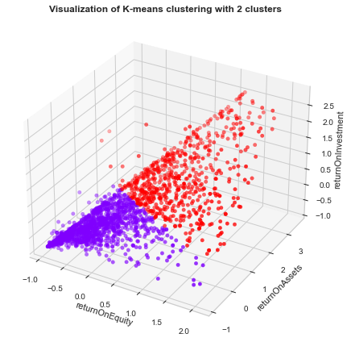

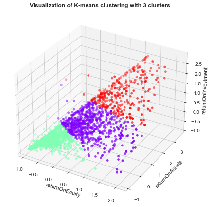

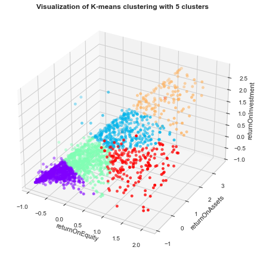

```python
clusters = [2,3,5]

for cluster in clusters:

    print('-'*120)

    kmeans = KMeans(n_clusters= cluster, random_state=0).fit(scaled_robust)

    centers = kmeans.cluster_centers_
    C1 = centers[:, 0]
    C2 = centers[:, 1]
    C3 = centers[:, 2]

    figure = plt.figure()
    a = Axes3D(figure)

    x = scaled_robust[:,0]
    y = scaled_robust[:,1]
    z = scaled_robust[:,2]

    names = attributes_df.columns
    a.set_xlabel(names[0])
    a.set_ylabel(names[1])
    a.set_zlabel(names[2])

    a.scatter(x, y, z, c = kmeans.labels_.astype(float), cmap='rainbow')
    a.scatter(C1, C2, C3, marker="x", color='red')

    plt.title('Visualization of K-means clustering with {} clusters'.format(cluster), fontweight='bold')

    plt.show()
```

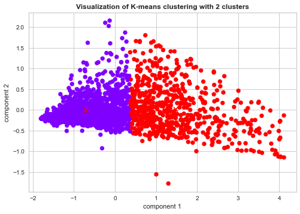

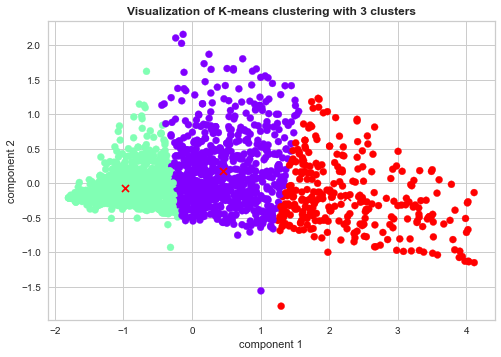

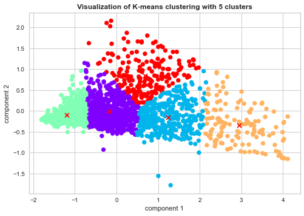

```python
clusters = [2,3,5]

for cluster in clusters:

    print('-'*120)

    kmeans = KMeans(n_clusters= cluster, random_state=0).fit(pca_dataset)

    centers = kmeans.cluster_centers_
    C1 = centers[:, 0]
    C2 = centers[:, 1]

    plt.figure()

    x = pca_dataset['component 1']
    y = pca_dataset['component 2']

    names = pca_dataset.columns
    plt.xlabel(names[0])
    plt.ylabel(names[1])

    plt.scatter(x, y, c=kmeans.labels_.astype(float), cmap='rainbow')
    plt.scatter(C1, C2, marker="x", color='red')

    plt.title('Visualization of K-means clustering with {} clusters'.format(cluster), fontweight='bold')
    plt.show()
```

As we can see, the clustering structure in both runs is similar. We get a 2D model instead of a 3D model in PCA as PCA is a dimensional reduction method. We can pinpoint which clusters have the wide silhouette based on their density. For example, in the 5 clusters model, the clusters on the left have incredibly high density with respect to the clusters on the left.

**Where are the outliers present?**

Outliers are usually present on the edges of the clustering, they are mostly promiment in the 3 clusters model between the left and the middle cluster.

**Why is there a difference in density?**

Usually most companies are present at the end of the model since they are subpar/average when they deliver on our metrics we chose (attributes), there are less companies doing above average, and even less companies doing extremely well on 1 metric or all metrics.

Now to apply our information. We test a sample of data we got from our attributes dataframe using 5 clusters in order to predict in which cluster the data will be present.

This will help us when predicting stocks to find out what stocks are related to each other in their behavior. Knowing this information, it helps us predict whichever stock is going to rise as a result of its sister stock in the cluster is rising.

```python
kmeans = results_dict[5]['model']

Company1 = [7.21890, 3.97467, 4.27593]
Company2 = [0.80941, 0.22374, 0.25863]
Company3 = [16.16998, 2.67732, 3.61774]
Company4 = [0.37223, 0.09081, 0.12745]
Company5 = [17.64532, 17.49922, 17.64532]

test = [Company1,Company2,Company3,Company4,Company5]

kmeans.predict(test)
```

```
array([3, 4, 3, 2, 3])
```

```python
attributes_df.head()

attributes_df.to_csv("attributes.csv")
```

# Conclusion

K-means clustering is an easy to understand unsupervised machine-learning clustering technique that is one of the most popular techniques used. Clustering is often accompanied with classification as the clusters already divide data into sets that need to be classified. While we did not apply classification in our model, we learned that there are similarities between some stocks based on the three attributes that we chose which are return on equity, return on assets, and return on investment.

The problems we faced in our model is the amount of density at the lower end of our metrics. This allows us to question choices in our approach to clulstering like if the metrics we chose were the best or if the K we chose is the most optimal one.

Moreover, this whole approach raises a lot of questions. How would our data perform with a different type of clustering algorithm? How would filtering the results impact our model? Does increasing or decreasing the threshold of our chosen attributes lead to a better silhouette score and hence better clustering?

This shows the importance of trial and error in K-means clustering. Approaching data is never perfect, and in order to find out the percentage of our success we must keep trying with different sets of datas, altering our metrics, or choosing different K and analyzing the results while comparing them with each other in order to find out what is the most optimal way to implement K-means clustering on stocks.